# STAT614 Final Assignment

Alyssa Langmeyer

2025-05-04

## R Markdown

Please read carefully BEFORE selecting “Take the Quiz”:

This is a timed assignment. Once you select “Take the Quiz”, you will have 3 hours to submit the assignment. If you accidently close the window, you can go back to this Exam and “resume”, however the clock will be running the entire time.

Datasets: There are 4 datasets you will need to download which will be available once you select “Take the Quiz”.

Submission: Before you hit “Submit this Quiz”, make sure you upload your R file. Unfortunately, as far as I can tell, there is no warning if you submit the quiz before uploading your file. If you forget to upload your R file, or you run out of time, and it automatically submits) don’t panic :). Just email me your R file. Everything is time-stamped so you MUST email me immediately.

Format: DO NOT answer any questions in the actual Exam. All your answers, code, plots, explanations etc. need to be contained in your R file. It will only allow you to upload 1 file so if for any reason you have more than 1 file (PDF for example), email me with the additional file.

If you have any questions or concerns about these instructions, make sure to reach out BEFORE selecting “Take the Quiz”.

Good luck! And remember to upload your R file before submitting

## Instructions for Final Assignment

For each of the data problems below, state what you think is the primary research question. Then go through all the steps you think are needed to best answer the question. Explain your reasoning for each step.

Steps to take: follow the general pattern we’ve been doing in HW assignments and the high school cheating problem from Exam 2.

Assumptions: if you assess an assumption, be specific as to which assumption you are assessing, and what your conclusions/assessments are.

Charts/Summaries: If you decide to run a plot or numerical summary, state the reason why (for each one) and your conclusion after seeing it.

Statistical method (only choose 1): state why you chose the method. Only use methods covered in this class.

Results: In a few sentences, interpret your results and state your conclusions as they pertain to the research question. Be sure to include values and uncertainty measures if and only if they are relevant to the research question.

Note on your explanations: except for your results/conclusions, everything should be concise (a few words to 1 sentence is fine).

Note on the data: you should feel free to use the existing data as is, add or remove variables, or remove observations. You can either do that in Excel before pulling the data into R, or do it in R using any code you are comfortable with. Here are some simple methods/examples using R:

To remove the variable “Age”:

newdata <- subset(olddata, select= - Age)

To add a variable “age in 5 years”:

newdata <- transform(olddata, age5 = Age+5)

To remove infants from a dataset:

newdata <- subset(olddata, Age>1)

~~~~~~~~~~~~~~~~~~~~~~~~~~~~~~~~~~~~~~~~~~~~~~~~~~~~~~~~~~~~~~~~~~~~~~~~~~~~~~~~~~~~~~~~~~~~~~~~~~~~~~~~~~

*For all data sets that include a “Gender” variable, men are coded as 0 (women as 1):

blood-1.csvDownload blood-1.csv

device.csvDownload device.csv

treadmill.csvDownload treadmill.csv

bikes-1.csvDownload bikes-1.csv

## Data Problem 1: “blood.csv”

Abuses/addiction of substances containing a toxic chemical can result in neurological symptoms. Investigators were interested in how various types of exposures can impact the level of that chemical found in blood samples. Mice were exposed under different conditions (Exposure) and measurements of the chemical (in parts per million) under those conditions were taken (BloodPPM). In addition to the “Exposure” variable, a recoded numerical variable (ExpGroup) is available, as well as dummies for each exposure condition.

Research Question: In what does the type of chemical exposure affect the level of BloodPPM in mice?

```r
# load data and review
blood <- read.csv("C:/Users/langm/OneDrive/Documents/PROGRAMMING/STAT614 - Statistical Methods/Final Exam/blood-1.csv")
head(blood)
```

```
##   Mouse BloodPPM Exposure ExpGroup Low Bursts Short Long
## 1     1    0.481     Low         1   1      0     0    0
## 2     2    0.584     Low         1   1      0     0    0
## 3     3    0.585     Low         1   1      0     0    0
## 4     4    0.628     Low         1   1      0     0    0
## 5     5    0.533     Low         1   1      0     0    0
## 6     6    0.490     Low         1   1      0     0    0
```

```r
summary(blood)
```

```
##      Mouse          BloodPPM        Exposure            ExpGroup
##  Min.   : 1.00   Min.   :0.4420   Length:60          Min.   :1.00
##  1st Qu.:15.75   1st Qu.:0.5847   Class :character   1st Qu.:1.75
##  Median :30.50   Median :0.8286   Mode  :character   Median :2.50
##  Mean   :30.50   Mean   :0.9259                      Mean   :2.50
##  3rd Qu.:45.25   3rd Qu.:1.1590                      3rd Qu.:3.25
##  Max.   :60.00   Max.   :1.8920                      Max.   :4.00
##       Low           Bursts         Short           Long
##  Min.   :0.00   Min.   :0.00   Min.   :0.00   Min.   :0.00
##  1st Qu.:0.00   1st Qu.:0.00   1st Qu.:0.00   1st Qu.:0.00
##  Median :0.00   Median :0.00   Median :0.00   Median :0.00
##  Mean   :0.25   Mean   :0.25   Mean   :0.25   Mean   :0.25
##  3rd Qu.:0.25   3rd Qu.:0.25   3rd Qu.:0.25   3rd Qu.:0.25
##  Max.   :1.00   Max.   :1.00   Max.   :1.00   Max.   :1.00
```

```r
# get basic data on the dataset
blood %>%
  group_by(Exposure) %>%
  summarise(
    Mean = mean(BloodPPM),
    SD = sd(BloodPPM),
    n = n()
  )
```

```
## # A tibble: 4 × 4
##   Exposure  Mean    SD     n
##   <chr>    <dbl> <dbl> <int>
## 1 "Bursts" 1.36  0.335    15
## 2 "Long"   1.16  0.285    15
## 3 "Low "   0.586 0.108    15
## 4 "Short"  0.595 0.108    15
```

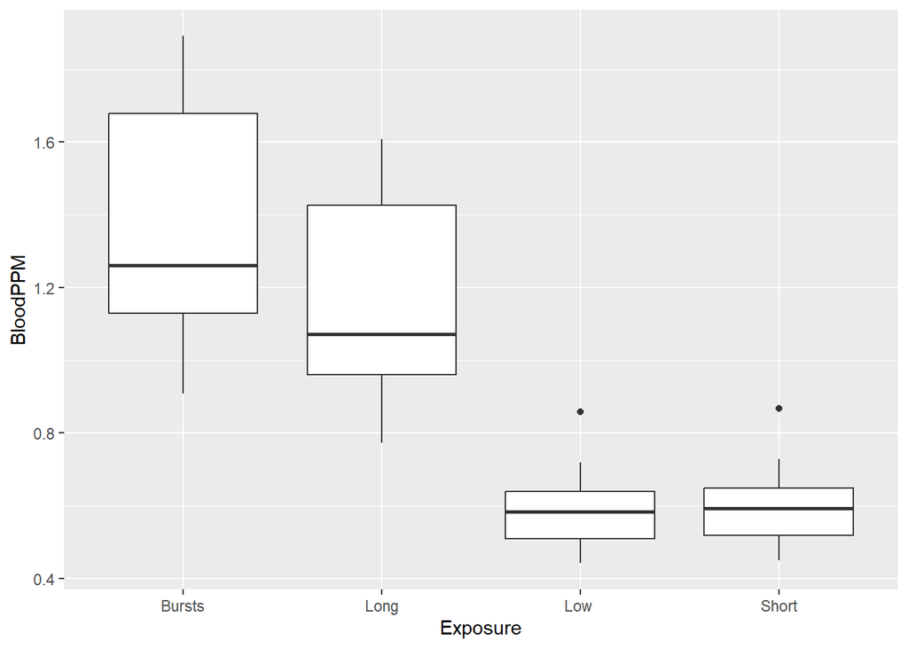

```r
# boxplot for visualization
ggplot(blood,aes(x=Exposure,y=BloodPPM,filll=Exposure))+
  geom_boxplot()
```

This boxplot visually shows the differences in their spreads and medians. As noted above, Burst and Long have higher variability than Low and Short and there does not appear to be any extreme outliers.

```r
# checking for normality
normality_tests <- tapply(blood$BloodPPM, blood$Exposure, shapiro.test)
print(normality_tests)
```

```
## $Bursts
##
##  Shapiro-Wilk normality test
##
## data:  X[[i]]
## W = 0.90279, p-value = 0.105
##
##
## $Long
##
##  Shapiro-Wilk normality test
##
## data:  X[[i]]
## W = 0.90279, p-value = 0.105
##
##
## $`Low `
##
##  Shapiro-Wilk normality test
##
## data:  X[[i]]
## W = 0.92536, p-value = 0.2323
##
##
## $Short
##
##  Shapiro-Wilk normality test
##
## data:  X[[i]]
## W = 0.92536, p-value = 0.2323
```

```r
# checking for equal variance
bartlett_result <- bartlett.test(BloodPPM ~ Exposure, data = blood)
print(bartlett_result)
```

```
##
##  Bartlett test of homogeneity of variances
##
## data:  BloodPPM by Exposure
## Bartlett's K-squared = 26.312, df = 3, p-value = 8.206e-06
```

```r
anova_model <- aov(BloodPPM ~ Exposure, data = blood)
anova_summary <- summary(anova_model)
print(anova_summary)
```

```
##             Df Sum Sq Mean Sq F value   Pr(>F)
## Exposure     3  7.044  2.3479   43.36 1.27e-14 ***
## Residuals   56  3.033  0.0542
## ---
## Signif. codes:  0 '***' 0.001 '**' 0.01 '*' 0.05 '.' 0.1 ' ' 1
```

The f-statistic means that at at least one of the exposure types differs from the others. This test tells that not all the means are equal

```r
# pairwise comparisons to determine which exposure groups differ in their BloodPPM levels
pairwise.t.test(blood$BloodPPM, blood$Exposure, p.adjust.method = "bonferroni")
```

```
##
##  Pairwise comparisons using t tests with pooled SD
##
## data:  blood$BloodPPM and blood$Exposure
##
##       Bursts  Long    Low
## Long  0.12    -       -
## Low   6.5e-12 5.7e-08 -
## Short 9.6e-12 8.6e-08 1.00
##
## P value adjustment method: bonferroni
```

Burst and Long have statistically similar exposures and Low and Short are statistically similar as well, but Burst and Long have higher BloomPPM than Low and Short do.

Conclusion: Due to the pairwaise test, we can see that Burst and Long exposures result in significantly higher BloodPPM levels than Short and Low do. There was no differences between Burst and Long or Low and Short.

## Data Problem 2: “device.csv”

A medical company developed a new device for counting proteins in blood (XB200) that is less expensive to manufacture than the current one on the market (XB100). Before upgrading all the hospitals with the new devices, they needed to make sure the new ones were just as accurate as the olds ones as there’s a suspicion that the new one is undercounting proteins.

Research Question: Does the XB200 protein counting device work as accurately as the older XB100 model?

Hypotheses: Null: The mean protein counts from XB200 and XB100 are equal to each other. Alt: The mean protein counts from XB200 are undercounted compared to XB100.

```r
# load data and review
device <- read.csv("C:/Users/langm/OneDrive/Documents/PROGRAMMING/STAT614 - Statistical Methods/Final Exam/device.csv")
head(device)
```

```
##   Patient.ID XB100 XB200 Gender
## 1      43538  13.4    16      1
## 2      43530   9.1    11      0
## 3      43506  10.3    12      1
## 4      43501  14.0    15      0
## 5      43516  22.2    23      1
## 6      43521  21.3    22      0
```

```r
summary(device)
```

```
##    Patient.ID        XB100           XB200            Gender
##  Min.   :43500   Min.   : 5.90   Min.   : 5.015   Min.   :0.0
##  1st Qu.:43510   1st Qu.:11.07   1st Qu.:11.356   1st Qu.:0.0
##  Median :43520   Median :16.05   Median :14.950   Median :0.5
##  Mean   :43520   Mean   :16.76   Mean   :15.109   Mean   :0.5
##  3rd Qu.:43529   3rd Qu.:21.30   3rd Qu.:18.615   3rd Qu.:1.0
##  Max.   :43539   Max.   :29.80   Max.   :26.000   Max.   :1.0
```

```r
# descriptive statistics for the differences in devices
summary(device$XB100 - device$XB200)
```

```
##    Min. 1st Qu.  Median    Mean 3rd Qu.    Max.
## -2.6000  0.9975  2.0125  1.6533  2.8537  4.4700
```

Assumptions check

```r
# checking for normality
shapiro.test(device$XB100 - device$XB200)
```

```
##
##  Shapiro-Wilk normality test
##
## data:  device$XB100 - device$XB200
## W = 0.94001, p-value = 0.03459
```

The p-value = 0.035, which is less than 0.05, so we know that the differences between the models are not normally distributed but the difference is not massive.

```r
# t-test as the samples are measured by both devices
t.test(device$XB100, device$XB200, paired = TRUE, alternative = "greater")
```

```
##
##  Paired t-test
##
## data:  device$XB100 and device$XB200
## t = 6.2523, df = 39, p-value = 1.156e-07
## alternative hypothesis: true mean difference is greater than 0
## 95 percent confidence interval:
##  1.207731      Inf
## sample estimates:
## mean difference
##         1.65325
```

The small p-value suggests that the XB100 model counts are higher than XB200, meaning that the XB200 might indeed not be as accurate. The Confidence Interval indicates that that the true difference in means is at least 1.21 higher in XB100 than XB200.

Conclusion: The extremely significant t-test result suggests that the XB200 models consistently under counts proteins compared to the XB100 model. This proves the alternative hypotheses and the company should review the bias in their machines.

## Data Problem 3: “treadmill.csv”

A company that makes treadmills is interested in how the usage of their 3 models differ from one another. The models include their low-end model (TM195), midrange (TM498), and high-end model (TM798). In addition to the product variable (Product), there is a recoded numeric project variable (ProdGrp), as well as dummy variables for each of the models. There are two variables related to usage, one for the number of miles walked/ran per week (Miles), as well as the number of days of the week that it was used (Days). The sales price, ie how much the customer paid (Price) is included as well.

Research Question: Hows does the usage patterns differ by treadmill model?

Hypotheses: Null: There is no difference in mean usage across models Alt: One of the models differs in mean usage.

```r
# load data and review
treadmill <- read.csv("C:/Users/langm/OneDrive/Documents/PROGRAMMING/STAT614 - Statistical Methods/Final Exam/treadmill.csv")
head(treadmill)
```

```
##   Product ProdGrp Price Miles Days TM195 TM498 TM798
## 1   TM195       1  1000    25    2     1     0     0
## 2   TM195       1  1000    25    2     1     0     0
## 3   TM195       1  1000    25    2     1     0     0
## 4   TM195       1  1000    35    2     1     0     0
## 5   TM195       1  1000    35    2     1     0     0
## 6   TM195       1  1000    35    2     1     0     0
```

```r
summary(treadmill)
```

```
##    Product             ProdGrp          Price          Miles
##  Length:180         Min.   :1.000   Min.   :1000   Min.   : 25.00
##  Class :character   1st Qu.:1.000   1st Qu.:1000   1st Qu.: 66.00
##  Mode  :character   Median :2.000   Median :1100   Median : 85.00
##                     Mean   :1.778   Mean   :1142   Mean   : 88.33
##                     3rd Qu.:2.000   3rd Qu.:1200   3rd Qu.:107.00
##                     Max.   :3.000   Max.   :1500   Max.   :240.00
##       Days           TM195            TM498            TM798
##  Min.   :2.000   Min.   :0.0000   Min.   :0.0000   Min.   :0.0000
##  1st Qu.:3.000   1st Qu.:0.0000   1st Qu.:0.0000   1st Qu.:0.0000
##  Median :3.000   Median :0.0000   Median :0.0000   Median :0.0000
##  Mean   :3.456   Mean   :0.4444   Mean   :0.3333   Mean   :0.2222
##  3rd Qu.:4.000   3rd Qu.:1.0000   3rd Qu.:1.0000   3rd Qu.:0.0000
##  Max.   :7.000   Max.   :1.0000   Max.   :1.0000   Max.   :1.0000
```

```r
# show the descriptive statistics for the differences in devices
treadmill %>%
  group_by(Product) %>%
  summarise(
    Mean_Miles = mean(Miles),
    SD_Miles = sd(Miles),
    Mean_Days = mean(Days),
    SD_Days = sd(Days),
    n = n()
  )
```

```
## # A tibble: 3 × 6
##   Product Mean_Miles SD_Miles Mean_Days SD_Days     n
##   <chr>        <dbl>    <dbl>     <dbl>   <dbl> <int>
## 1 TM195         77.5     33.1      3.09   0.783    80
## 2 TM498         85.8     32.8      3.07   0.800    60
## 3 TM798        114.      34.2      4.78   0.947    40
```

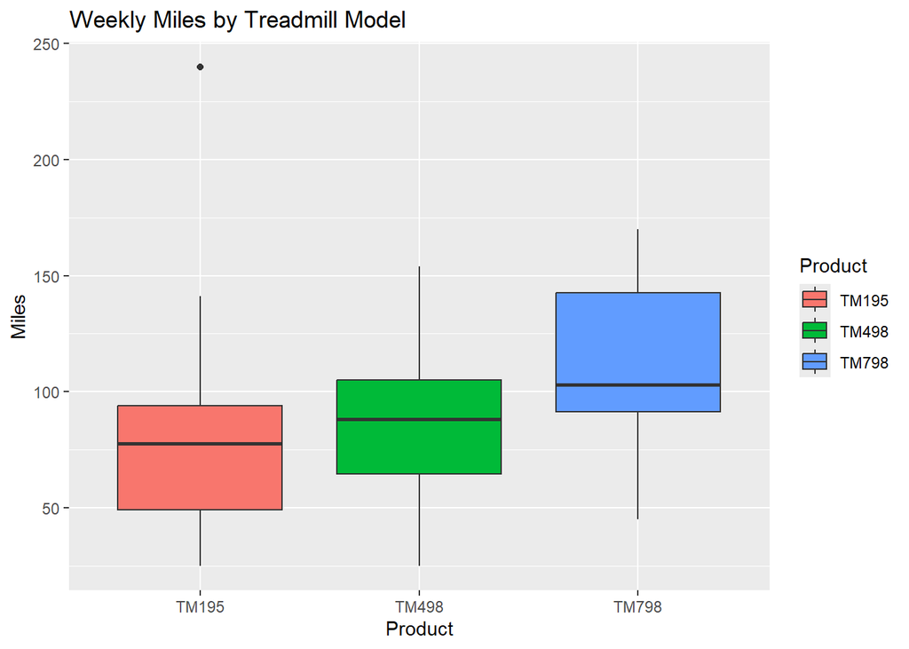

```r
# 2 boxplots for visualization
ggplot(treadmill, aes(x = Product, y = Miles, fill = Product)) +
  geom_boxplot() +
  labs(title = "Weekly Miles by Treadmill Model")
```

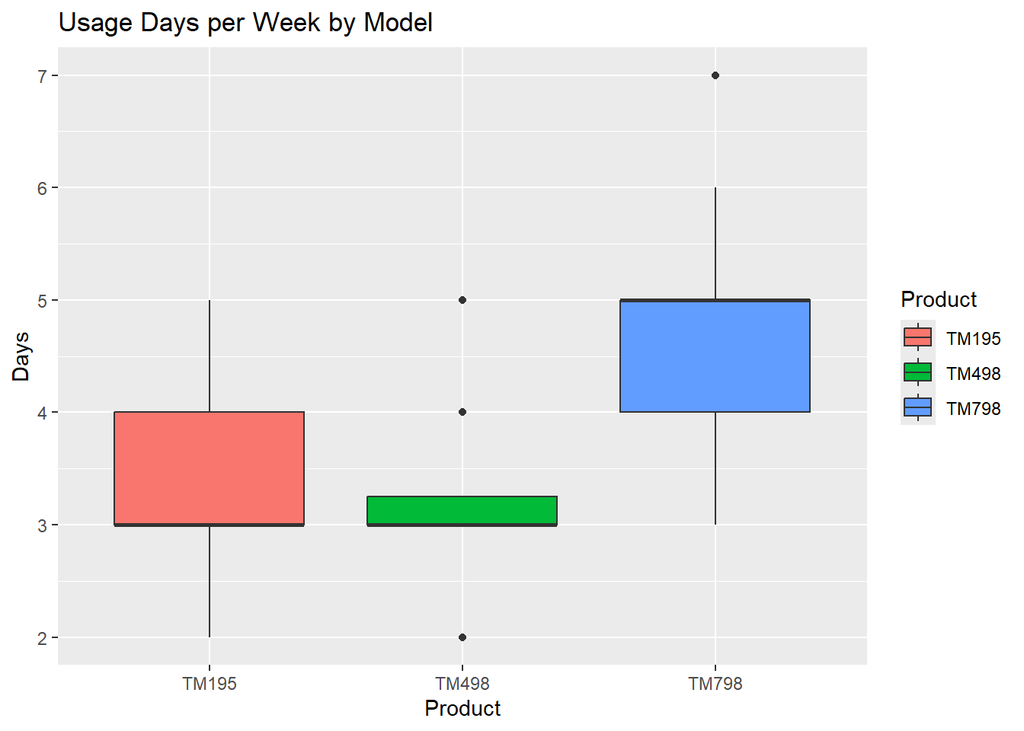

```r
ggplot(treadmill, aes(x = Product, y = Days, fill = Product)) +
  geom_boxplot() +
  labs(title = "Usage Days per Week by Model")
```

We can see that TM798 shows higher median miles and higher average weekly usage than the other models.

Assumption Checks

```r
# check for normality
tapply(treadmill$Miles, treadmill$Product, shapiro.test)
```

```
## $TM195
##
##  Shapiro-Wilk normality test
##
## data:  X[[i]]
## W = 0.88904, p-value = 4.324e-06
##
##
## $TM498
##
##  Shapiro-Wilk normality test
##
## data:  X[[i]]
## W = 0.95289, p-value = 0.02134
##
##
## $TM798
##
##  Shapiro-Wilk normality test
##
## data:  X[[i]]
## W = 0.94217, p-value = 0.04093
```

```r
# check for equal variance
bartlett.test(Miles ~ Product, data = treadmill)
```

```
##
##  Bartlett test of homogeneity of variances
##
## data:  Miles by Product
## Bartlett's K-squared = 0.094997, df = 2, p-value = 0.9536
```

The normality tests (and the p-values) show that all groups violate normality. The equal vairance is confirmed, as the p-value = 0.954, which is greater than 0.05. ANOVA

```r
miles_anova <- aov(Miles ~ Product, data = treadmill)
summary(miles_anova)
```

```
##              Df Sum Sq Mean Sq F value   Pr(>F)
## Product       2  35610   17805   16.09 3.78e-07 ***
## Residuals   177 195816    1106
## ---
## Signif. codes:  0 '***' 0.001 '**' 0.01 '*' 0.05 '.' 0.1 ' ' 1
```

The one-sided anova test finds that there is strong evidence again the null hypothesis and that a least one treadmill model differs significantly in the number of miles weekly.

## Data Problem 4: “bikes.csv”

Research Question: Did cyclist on the East Coast bike more or less than those on the West Coast during the COVID pandemic?

Hypotheses: Null: There is no difference in mean annual kilometers biked in between the coasts after accounting for age and gender. Alt: There is a difference in mean annual kilometers biked in between the coasts after accounting for age and gender.

```r
# load and review data
bikes <- read.csv("C:/Users/langm/OneDrive/Documents/PROGRAMMING/STAT614 - Statistical Methods/Final Exam/bikes-1.csv")
head(bikes)
```

```
##   Coast   KM Gender Age
## 1  East 2553      0  25
## 2  East 2502      0  25
## 3  East 1698      0  26
## 4  East 1664      0  26
## 5  West 1571      0  32
## 6  East 1540      0  27
```

```r
summary(bikes)
```

```
##     Coast                 KM              Gender            Age
##  Length:204         Min.   :   1.00   Min.   :0.0000   Min.   :25.00
##  Class :character   1st Qu.:  21.75   1st Qu.:0.0000   1st Qu.:27.00
##  Mode  :character   Median :  82.50   Median :1.0000   Median :30.00
##                     Mean   : 219.58   Mean   :0.5294   Mean   :30.03
##                     3rd Qu.: 223.00   3rd Qu.:1.0000   3rd Qu.:33.00
##                     Max.   :2553.00   Max.   :1.0000   Max.   :35.00
```

```r
# show descriptive statistics for each coast
bikes %>%
  group_by(Coast) %>%
  summarise(
    Mean_KM = mean(KM),
    SD_KM = sd(KM),
    Mean_Age = mean(Age),
    SD_Age = sd(Age),
    n = n()
  )
```

```
## # A tibble: 2 × 6
##   Coast Mean_KM SD_KM Mean_Age SD_Age     n
##   <chr>   <dbl> <dbl>    <dbl>  <dbl> <int>
## 1 East     272.  472.     29.7   3.12   102
## 2 West     167.  290.     30.3   3.13   102
```

The east coast has higher mean kilometers at 271.8922 km/yr compared to the 167.2647 km/yr on the West Coast. The average age is similiar between both groups, at 29.73 and 30.33

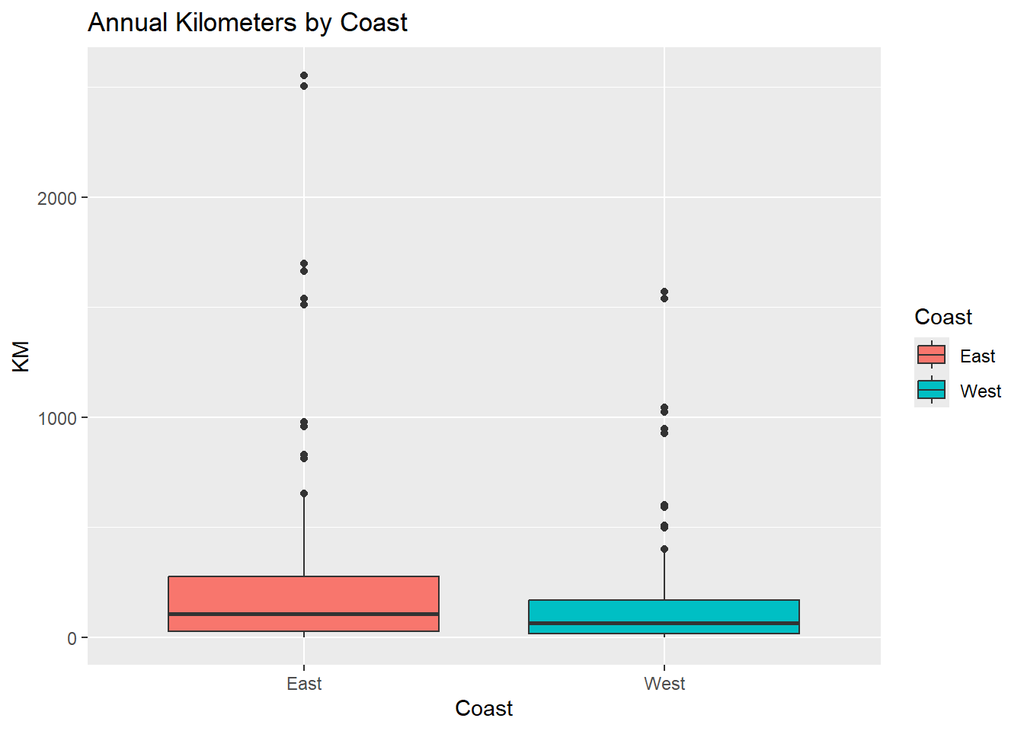

```r
# boxplot for visualization
ggplot(bikes, aes(x = Coast, y = KM, fill = Coast)) +
  geom_boxplot() +
  labs(title = "Annual Kilometers by Coast")
```

We can see that the East Coast has higher median km biked than those on the west coast do, but that the east has more outliers.

```r
# mult regression w/ age and gender
bike_model <- lm(KM ~ Coast + Age + Gender, data = bikes)
summary(bike_model)
```

```
##
## Call:
## lm(formula = KM ~ Coast + Age + Gender, data = bikes)
##
## Residuals:
##     Min      1Q  Median      3Q     Max
## -403.90 -200.61  -86.32   50.25 2028.90
##
## Coefficients:
##             Estimate Std. Error t value Pr(>|t|)
## (Intercept) 1064.753    255.402   4.169 4.56e-05 ***
## CoastWest   -102.197     51.476  -1.985   0.0485 *
## Age          -21.626      8.319  -2.600   0.0100 *
## Gender      -273.237     51.846  -5.270 3.52e-07 ***
## ---
## Signif. codes:  0 '***' 0.001 '**' 0.01 '*' 0.05 '.' 0.1 ' ' 1
##
## Residual standard error: 365.7 on 200 degrees of freedom
## Multiple R-squared:  0.1508, Adjusted R-squared:  0.138
## F-statistic: 11.83 on 3 and 200 DF,  p-value: 3.617e-07
```

```r
confint(bike_model)
```

```
##                  2.5 %       97.5 %
## (Intercept)  561.12722 1568.3778166
## CoastWest   -203.70256   -0.6920607
## Age          -38.03047   -5.2218400
## Gender      -375.47240 -171.0011983
```

Conclusion: The alternative hypothesis is correct, there is a difference. West Coast cyclists biked 102.2 fewer km/yr than the east coast. Each additional year of age was associated with 21.6 fewer km/yr and gender had a significant effect.

## Notes

Hi Professor, apologies if this isn’t the cleanest or if I missed some explanation somewher things, I ran out of time and didn’t get to do a proper review.

Thank you for a great semester as well, and I hope you have a great summer!!